# P8105_hw6_ja3314

Jaisal Amin

## Problem 1

**Importing and cleaning the data :**

```r
url = "https://raw.githubusercontent.com/washingtonpost/data-homicides/master/homicide-data.csv"
raw_data = read_csv(url) %>%
  mutate(city_state = str_c(city, ",", " ", state)) %>%
  mutate(resolved = as.numeric(disposition == "Closed by arrest"),
         victim_age = as.numeric(victim_age),
         victim_race = ifelse(victim_race == "White", c("White"), c("Non-white")),
         victim_race = fct_relevel(victim_race, "White")) %>%
  filter(!city_state %in% c("Tulsa, AL", "Dallas, TX", "Phoenix, AZ", "Kansas City, MO"))
```

**Fitting logistic regression for Baltimore:**

```r
baltimore_df =
  raw_data %>%
  filter(city_state == "Baltimore, MD") %>%
  select(resolved, victim_age, victim_race, victim_sex)

fit_logistic =
  baltimore_df %>%
  glm(resolved ~ victim_age + victim_race + victim_sex, data = ., family = binomial())
```

**Making table with relevant info:**

```r
fit_logistic %>%
  broom::tidy() %>%
  mutate(OR = exp(estimate),
         OR_lower_bound = exp(estimate - 1.96*std.error),
         OR_upper_bound = exp(estimate + 1.96*std.error)) %>%
  select(term, starts_with("OR")) %>%
  knitr::kable(digits = 3)
```

| term | OR | OR_lower_bound | OR_upper_bound |
| --- | --- | --- | --- |
| (Intercept) | 3.274 | 2.067 | 5.186 |
| victim_age | 0.993 | 0.987 | 0.999 |
| victim_raceNon-white | 0.441 | 0.313 | 0.620 |
| victim_sexMale | 0.412 | 0.315 | 0.537 |

Based on the values obtained, the odds of a homicide of a non-white victim being solved in Baltimore are 0.441 times the odds of a homicide of a white victim being resolved, all else being equal. We are 95% confidence that the true odds ratio falls between 0.313 and 0.620.

**Running regressions for all cities in dataset:**

```r
city_glm =
  raw_data %>%
  group_by(city_state) %>%
  nest() %>%
  mutate(models = map(data, ~glm(resolved ~ victim_age + victim_race + victim_sex, data = ., family = binomial())),
         models = map(models, broom::tidy)) %>%
  select(-data) %>%
  unnest() %>%
  mutate(OR = exp(estimate),
         OR_upper_bound = exp(estimate + 1.96*std.error),
         OR_lower_bound = exp(estimate - 1.96*std.error)) %>%
  select(city_state, term, starts_with("OR")) %>%
  filter(term == "victim_raceNon-white")
```

**Plotting odds ratios and confidence intervals:**

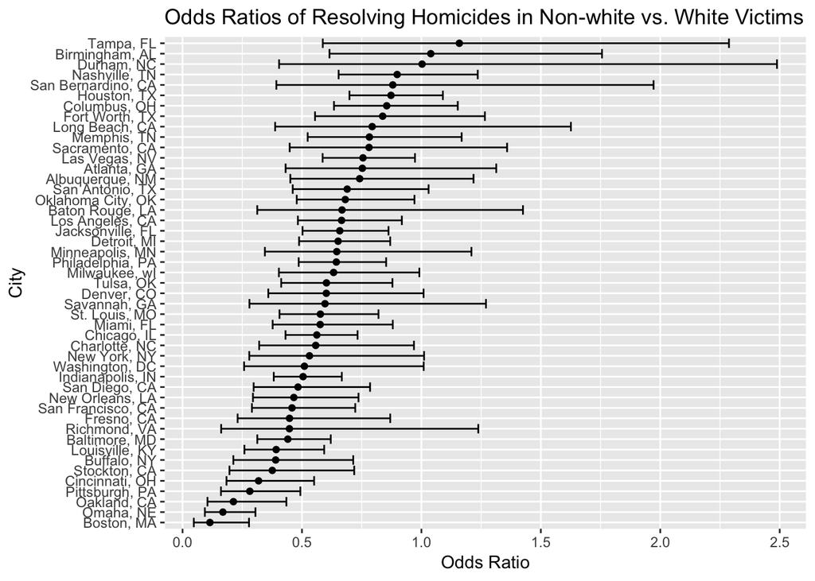

```r
city_glm %>%
  mutate(city_state = fct_reorder(city_state, OR)) %>%
  ggplot(aes(x = city_state, y = OR)) +
    geom_point() +
    coord_flip() +
    geom_errorbar(aes(ymin = OR_lower_bound, ymax = OR_upper_bound)) +
    labs(x = "City", y = "Odds Ratio", title = "Odds Ratios of Resolving Homicides in Non-white vs. White Victims")
```

From looking at this plot, we see that the odds ratios of homicide resolution in non-white victims is lower than 1 for most cities, meaning that white victims are more likely to have their homicides resolved. Many confidence intervals include 1 but most range below 1.

## Problem 2

**Reading in data :**

```r
birthweight_df = read_csv("./data/birthweight.csv") %>%
  mutate(babysex = as.factor(babysex),
         malform = as.factor(malform),
         frace = as.factor(frace),
         mrace = as.factor(mrace))
```

**Creating first model and plotting residuals:**

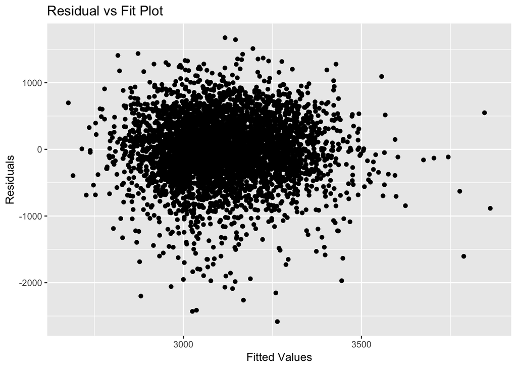

```r
birthweight_model_1 = lm(bwt ~ ppwt + momage + fincome + smoken + babysex, data = birthweight_df)

birthweight_df %>%
  add_predictions(., birthweight_model_1) %>%
  add_residuals(., birthweight_model_1) %>%
  ggplot(aes(x = pred, y = resid)) +
    geom_point() +
    labs(x = "Fitted Values", y = "Residuals", title = "Residual vs Fit Plot")
```

For this regression, I chose to look at mother’s weight, age, income, smoking status and the baby’s sex as predictors of birthweight. Research has suggested that all of these factors may play a role in influencing a baby’s birth weight. The residual graph shows a general concentration of values around 0 however there are quite a few outliers, suggesting that there are some things this model is not accounting for.

**Creating additional models:**

```r
birthweight_model_2 = lm(bwt ~ blength + gaweeks, data = birthweight_df)
birthweight_model_3 = lm(bwt ~ bhead + blength + babysex + bhead * blength  + bhead * babysex + blength * babysex + bhead * blength * babysex, data = birthweight_df)
```

**Creating cross validation dataset:**

```r
crossv_df =
  crossv_mc(birthweight_df, 100) %>%
  mutate(train = map(train, as_tibble),
         test = map(test, as_tibble)) %>%
  mutate(birthweight_model_1 = map(train, ~ lm(bwt ~ ppwt + momage + fincome + smoken + babysex, data = birthweight_df)),
         birthweight_model_2 = map(train, ~ lm(bwt ~ blength + gaweeks, data = birthweight_df)),
         birthweight_model_3 = map(train, ~ lm(bwt ~ bhead + blength + babysex + bhead * blength  + bhead * babysex + blength * babysex + bhead * blength * babysex, data = birthweight_df))) %>%
  mutate(rmse_1 = map2_dbl(birthweight_model_1, test, ~ rmse(model = .x, data = .y)),
         rmse_2 = map2_dbl(birthweight_model_2, test, ~ rmse(model = .x, data = .y)),
         rmse_3 = map2_dbl(birthweight_model_3, test, ~ rmse(model = .x, data = .y)))
```

Here I created a cross validation dataset with 100 pairs for testing and training and calculated RMSEs.

**Visualizing RMSE distributions:**

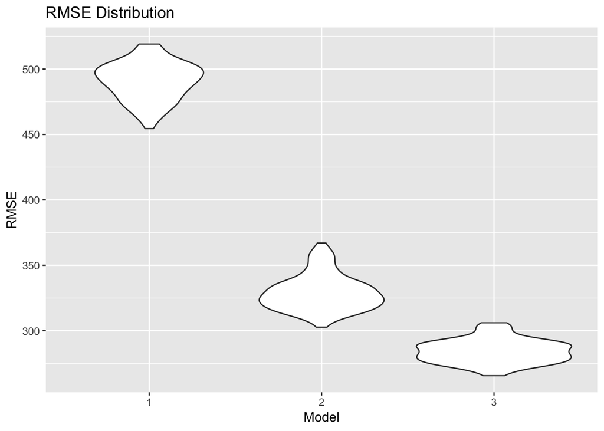

```r
crossv_df %>%
  select(starts_with("rmse")) %>%
  gather(key = model, value = rmse) %>%
  mutate(model = str_replace(model, "rmse_", ""),
         model = fct_inorder(model)) %>%
  ggplot(aes(x = model, y = rmse)) +
    geom_violin() +
    labs(x = "Model", y = "RMSE", title = "RMSE Distribution")
```

Here we can see that my first model is not the best predictor but models 2 and 3 are both decent predictive models.